# my_project_ml

Ana Belen Nieto Librero

7/1/2020

# Background

Using devices such as Jawbone Up, Nike FuelBand, and Fitbit it is now possible to collect a large amount of data about personal activity relatively inexpensively. These type of devices are part of the quantified self movement (a group of enthusiasts who take measurements about themselves regularly to improve their health, to find patterns in their behavior, or because they are tech geeks). One thing that people regularly do is quantify how much of a particular activity they do, but they rarely quantify how well they do it. In this project, your goal will be to use data from accelerometers on the belt, forearm, arm, and dumbell of 6 participants. They were asked to perform barbell lifts correctly and incorrectly in 5 different ways. More information is available from the website here: [link]{http://groupware.les.inf.puc-rio.br/har} (see the section on the Weight Lifting Exercise Dataset).

# Data

The training data for this project are available here:

[link]{https://d396qusza40orc.cloudfront.net/predmachlearn/pml-training.csv}

The test data are available here:

[link]{https://d396qusza40orc.cloudfront.net/predmachlearn/pml-testing.csv}

The data for this project come from this source: [link]{http://groupware.les.inf.puc-rio.br/har}.

Our outcome variable is classe, a factor variable with 5 levels. For this data set, participants were asked to perform one set of 10 repetitions of the Unilateral Dumbbell Biceps Curl in 5 different fashions:

exactly according to the specification (Class A)

throwing the elbows to the front (Class B)

lifting the dumbbell only halfway (Class C)

lowering the dumbbell only halfway (Class D)

throwing the hips to the front (Class E)?

Class A corresponds to the specified execution of the exercise, while the other 4 classes correspond to common mistakes."

Prediction evaluations will be based on maximizing the accuracy and minimizing the out-of-sample error. All other available variables after cleaning will be used for prediction.

Two models will be tested using decision tree and random forest algorithms. The model with the highest accuracy will be chosen as our final model.

# Goal

The goal of your project is to predict the manner in which they did the exercise. This is the “classe” variable in the training set. You may use any of the other variables to predict with. You should create a report describing how you built your model, how you used cross validation, what you think the expected out of sample error is, and why you made the choices you did. You will also use your prediction model to predict 20 different test cases.

# Loading data and the libraries

```r
library(caret)
```

```r
library(rpart)
library(rpart.plot)
library(RColorBrewer)
library(rattle)
library(e1071)
library(randomForest)
library(doMC)
set.seed(111)
# read the data
traindata <- read.csv("pml-training.csv", na.strings = c("NA", "#DIV/0!", ""))
testdata  <- read.csv("pml-testing.csv", na.strings = c("NA", "#DIV/0!", ""))

# remove NA columns
completes <- complete.cases(t(traindata)) & complete.cases(t(testdata))
mytraindata <- traindata[,completes]
mytestdata  <- testdata[,completes]

# remove columns with data that isn't useful
mytraindata <- mytraindata[,-c(1,3,4,5,6,7)]
mytestdata <- mytestdata[,-c(1,3,4,5,6,7)]
dim(mytraindata)
```

```
## [1] 19622    54
```

```r
colnames(mytraindata)
```

```
##  [1] "user_name"            "roll_belt"            "pitch_belt"
##  [4] "yaw_belt"             "total_accel_belt"     "gyros_belt_x"
##  [7] "gyros_belt_y"         "gyros_belt_z"         "accel_belt_x"
## [10] "accel_belt_y"         "accel_belt_z"         "magnet_belt_x"
## [13] "magnet_belt_y"        "magnet_belt_z"        "roll_arm"
## [16] "pitch_arm"            "yaw_arm"              "total_accel_arm"
## [19] "gyros_arm_x"          "gyros_arm_y"          "gyros_arm_z"
## [22] "accel_arm_x"          "accel_arm_y"          "accel_arm_z"
## [25] "magnet_arm_x"         "magnet_arm_y"         "magnet_arm_z"
## [28] "roll_dumbbell"        "pitch_dumbbell"       "yaw_dumbbell"
## [31] "total_accel_dumbbell" "gyros_dumbbell_x"     "gyros_dumbbell_y"
## [34] "gyros_dumbbell_z"     "accel_dumbbell_x"     "accel_dumbbell_y"
## [37] "accel_dumbbell_z"     "magnet_dumbbell_x"    "magnet_dumbbell_y"
## [40] "magnet_dumbbell_z"    "roll_forearm"         "pitch_forearm"
## [43] "yaw_forearm"          "total_accel_forearm"  "gyros_forearm_x"
## [46] "gyros_forearm_y"      "gyros_forearm_z"      "accel_forearm_x"
## [49] "accel_forearm_y"      "accel_forearm_z"      "magnet_forearm_x"
## [52] "magnet_forearm_y"     "magnet_forearm_z"     "classe"
```

# Create sets for use cross validation

Select the 70% of the rows to train the model and the rest 30% to test the model.

```r
trainindex <- createDataPartition(y=mytraindata$classe,p=.70,list=F)
train <- mytraindata[trainindex,]
validation <- mytraindata[-trainindex,]
```

# Principal Component Analysis

To provide an overview in a reduced dimension of the training data we use the Principal Component Analysis with diferent number of components to be retained.

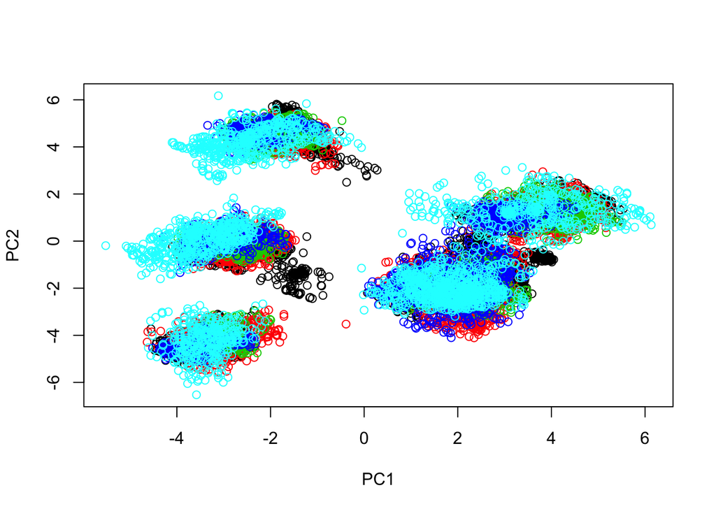

```r
prePCA <- preProcess(train[,-c(1,54)],method="pca",thresh=.8)
prePCA <- preProcess(train[,-c(1,54)],method="pca",thresh=.10)
prePCA <- preProcess(train[,-c(1,54)],method="pca",thresh=.95)
prePCA <- preProcess(train[,-c(1,54)],method="pca",pcaComp=25)
#prePCA$rotation
trainPCA <- predict(prePCA,train[,-c(1,54)])
plot(trainPCA[,c("PC1","PC2")],col=train$classe)
```

# Random Forest

The first model used was Random Forest.

```r
control.params <- trainControl(method="cv", 5)
rf.model <- train(classe ~ ., data=train, method="rf",
                 trControl=control.params, ntree=251)
rf.model
```

```
## Random Forest
##
## 13737 samples
##    53 predictor
##     5 classes: 'A', 'B', 'C', 'D', 'E'
##
## No pre-processing
## Resampling: Cross-Validated (5 fold)
## Summary of sample sizes: 10989, 10988, 10989, 10991, 10991
## Resampling results across tuning parameters:
##
##   mtry  Accuracy   Kappa
##    2    0.9898079  0.9871043
##   29    0.9913374  0.9890414
##   57    0.9837664  0.9794649
##
## Accuracy was used to select the optimal model using the largest value.
## The final value used for the model was mtry = 29.
```

# Performance

```r
rf.predict <- predict(rf.model, train)
confusionMatrix(train$classe, rf.predict)[3]
```

```
## $overall
##       Accuracy          Kappa  AccuracyLower  AccuracyUpper   AccuracyNull
##      1.0000000      1.0000000      0.9997315      1.0000000      0.2843416
## AccuracyPValue  McnemarPValue
##      0.0000000            NaN
```

# Validation

```r
rf.predict.val <- predict(rf.model, validation)
confusionMatrix(validation$classe, rf.predict.val)[3]
```

```
## $overall
##       Accuracy          Kappa  AccuracyLower  AccuracyUpper   AccuracyNull
##      0.9918437      0.9896838      0.9892003      0.9939802      0.2842821
## AccuracyPValue  McnemarPValue
##      0.0000000            NaN
```

# Decision tree

The second model used was a decision tree.

```r
modelDT <- rpart(classe ~ ., data=train, method="class")
predictionDT <- predict(modelDT, validation, type = "class")
confusionMatrix(validation$classe, predictionDT)[3]
```

```
## $overall
##       Accuracy          Kappa  AccuracyLower  AccuracyUpper   AccuracyNull
##   7.439252e-01   6.751163e-01   7.325698e-01   7.550383e-01   3.107901e-01
## AccuracyPValue  McnemarPValue
##   0.000000e+00   3.867841e-30
```

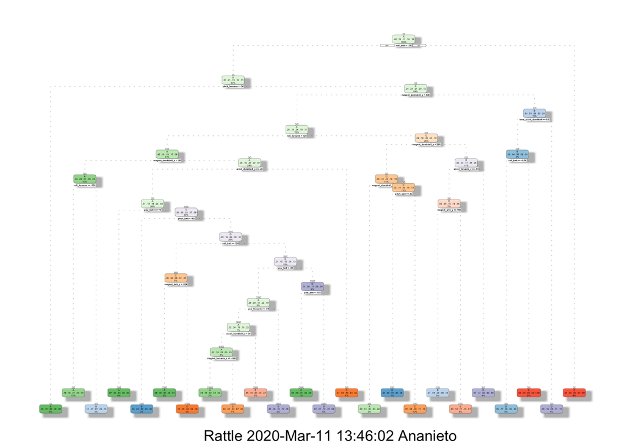

```r
fancyRpartPlot(modelDT)
```

The accuracy of the this model is lower than the accuracy of Random Forest.

# Decision

The best model to predict the classe is Random Forest.

## Quiz anwers

```r
rf.predict.test <- predict(rf.model, mytestdata)
rf.predict.test
```

```
##  [1] B A B A A E D B A A B C B A E E A B B B
## Levels: A B C D E
```